# ANU Student Research Conference Workshop: Introduction to R https://bit.ly/2kGO4I1

#### Data frames

Data frames are heterogeneous equivalents of matrices (heterogeneous means they can store data of various types): Each column can be of different data type, but within each column, all rows must be of the same data type. A bit like a simple spreadsheet (e.g. in Excel). Data frames are the basic, most comonly used data structures for storing and analyzing of the experimental data.  
So, let’s create a data frame with data as in the table below:

[output not shown]

To create a data frame we use a function called… `data.frame`.  
We need to specify each column as a separate vector. All the vectores (columns) need the have the same number of elements (rows)

```r
animals <- data.frame(animal = c("dog",   "cat",   "sea cucumber", "sea urchin"),
                        feel = c("furry", "furry", "squishy",      "spiny"),
                      weight = c(45,      8,       1.1,            0.8)
)

animals
```

```
##         animal    feel weight
## 1          dog   furry   45.0
## 2          cat   furry    8.0
## 3 sea cucumber squishy    1.1
## 4   sea urchin   spiny    0.8
```

Now, when we have our data in the `data.frame` structure we can save it as a file.  
R can work with many data file formats but the most popular ones are text files with fields separated either by a <TAB> or ‘,’ (coma). Those formats are know as ‘tab-separated values’ (TSV) and ‘coma-separated values’ (CSV). To save our `data.frame` as a file we can use the function `write.table()`.

```r
write.table(animals, file = "animals.tsv", sep = "\t", col.names = TRUE, row.names = FALSE, quote = FALSE)
```

> Arguments to specify when writing a data.frame as a file:
> - file - name of the file
> - sep - character to use as a separator, \t is tabulator
> - col.names - save column names?
> - row.names - save row names?
> - quote - surround non-numeric values in double-quotes?

Having the file created, we can now read the data back from file to a `data.frame` with function `read.table()`

```r
animals <- read.table(file = "animals.tsv", sep = "\t", header = TRUE)
```

Data frame and matrix can be converted into each other with functions `as.matrix()`, to convert `data.frame` into `matrix` or `as.data.frame()` to do the oposite.

> Remember that `data.frame` is **heterogeneous** but `matrix` is **homogenous**. Conversion of `data.frame` into `matrix` **may result in type coercion**.

#### Subsetting and Indexing

Now we know (sort of) how to perform operation of vectors, matrices and data.frames. But how to access specific elements in vectors or rows or columns of data in data frames? Rephrasing: How to **subset** a data structure?

Subsetting is done with use of indices. To access *n<sup>th</sup>* element of a vector *v* we use notation: *v*[*n*]. `[ ]` is the *indexing operator*.

```r
v <- 1:10     #create a vector with integer numbers from 1 to 10
v
```

```
##  [1]  1  2  3  4  5  6  7  8  9 10
```

```r
#get 1st element
v[1]
```

```
## [1] 1
```

```r
#get 7th element
v[7]
```

```
## [1] 7
```

```r
#get elements from 3 to 6
v[3:6]
```

```
## [1] 3 4 5 6
```

Similarly we use indeces to access elements in matrix; only this time we need to use two indices - **first for the row**, and **second for the column**.
Lets get back to our matrix *M*:
$$M = \begin{pmatrix}1 & 2 & 3 & 4 \\ 5 & 6 & 7 & 8 \\ 9 & 10 & 11 & 12\end{pmatrix}$$

```r
M <- matrix(1:12, nrow = 3, ncol = 4, byrow = TRUE)
M
```

```
##      [,1] [,2] [,3] [,4]
## [1,]    1    2    3    4
## [2,]    5    6    7    8
## [3,]    9   10   11   12
```

```r
#get element in second row, third column
M[2, 3]
```

```
## [1] 7
```

```r
#to get all elements from a row or a column simply ommit row or column index:
M[2, ]    #returns second row as a vector
```

```
## [1] 5 6 7 8
```

```r
M[, 3]    #return third column as a vector
```

```
## [1]  3  7 11
```

Data frames can be indexed in the same way as matrices using the `[ ]` operator. Additionally the columns in the data frames may be accessed with the *dollar* `$` operator.  
Lets go back to the `animals` data frame:

[output not shown]

To access the columns we use `$`:

```r
animals$animal   #to access column animal
```

```
## [1] dog          cat          sea cucumber sea urchin
## Levels: cat dog sea cucumber sea urchin
```

```r
animals$feel     #to access column feel
```

```
## [1] furry   furry   squishy spiny
## Levels: furry spiny squishy
```

```r
animals$weight   #to access column weight
```

```
## [1] 45.0  8.0  1.1  0.8
```

Each column in a data frame is a *vector*, so we can use logical expressions, e.g.:

```r
animals$weight >= 4
```

```
## [1]  TRUE  TRUE FALSE FALSE
```

And now, nothing can stop us from using this expression to index, **subset** the data frame:

```r
animals[animals$weight >= 4, ]
```

```
##   animal  feel weight
## 1    dog furry     45
## 2    cat furry      8
```

> Remember, first index is for rows, second is for columns. When an index is missing it means *return all*. In the example above we are selecting, or *subsetting* rows and getting all the collumns.

# Golden Orb-Weaver Spider Project

Finally, we can start working on the data from our project!

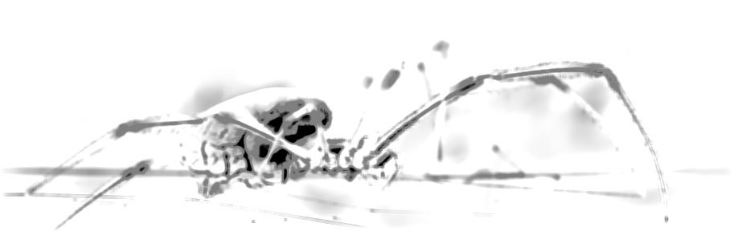

Scenario: We are part of a team studding Ecology of Golden Orb-Weaver spiders (*Nephila edulis*). The research objective is to compare spider populations living in different climate zones in Australia:

- Cool-Temperature Inland - Canberra, ACT
- Mid-Temperature Coastal - Jervis Bay, ACT
- Alpine - Cooma, NSW

The plan is to compare body weight of the spider with the diameter of the web the spider weaves and asses two hypothesis:

1. Bigger and heavier spiders make larger webs.
2. The climate where spiders live affects weight of the spiders and the size of their webs.

- spider_id - identifier of the spider (sp_1, sp_2, sp_3…),
- population - location where the spider was assesd (canberra, cooma, jervis),
- web_dia - diameter of the web the spider weaved (numerical values),
- weight - weight of the spider (numerical values).

We are **The Quantitative Researcher** in the team - this is our task to process and analyze the data:

- Present the data in graphical format on series of explanatory plots and graphs.
- Perform statistical test to prove that the climate indeed affects the size of the web.
- When performing our research we must adhere the most important rule of science - **The Reproducibility**. We will create a workflow, a program in R which can be re-run to reproduce our findings.

## Get the data

1. Download the project data file ‘spider_web.tsv’ from https://github.com/numicator/ANU_Student_Research_Conference/raw/master/spider.tsv and save it in your project’s directory.
2. Load data from “spider.tsv” file into data frame named variable `spider`.

Ensure that you checked:

- What is the column separator character?
- Does the file have a header?

```r
# load the data file into data frame
spider <- read.table("spider.tsv", sep = "\t", header = TRUE)
```

> It is also possible to use the *Import Dataset* feature from the **Environment** panel in RStudio.

## Quick data exploration:

- Check that the variable `spider` is indeed a `data.frame` with function `class()`.
- Reveal structure of the data frames with `str()` function.
- Print 5 first rows of the data with the `head()` function.
- Get basic statistics of the data with the `summary()` function.
- Print number of rows in the data frame with the `nrow()` function.
- **See** the data - generate *basic* plots.

Checking that `spider`is a `data.frame` object:

```r
print(paste("spider variable is", class(spider)))
```

```
## [1] "spider variable is data.frame"
```

Revealing its internal structure

```r
print("spider structure:")
```

```
## [1] "spider structure:"
```

```r
str(spider)
```

```
## 'data.frame':    290 obs. of  4 variables:
##  $ spider_id : Factor w/ 290 levels "sp_1","sp_10",..: 1 2 3 13 24 35 45 56 67 78 ...
##  $ population: Factor w/ 3 levels "canberra","cooma",..: 1 1 1 1 1 1 1 1 1 1 ...
##  $ web_dia   : num  90.2 101.2 99.5 105.9 104.4 ...
##  $ weight    : num  9.29 9.39 9.56 10.93 10.23 ...
```

Printing out a few first rows

```r
print("spider:")
```

```
## [1] "spider:"
```

```r
head(spider, n = 5)
```

```
##   spider_id population web_dia weight
## 1      sp_1   canberra   90.21   9.29
## 2     sp_10   canberra  101.23   9.39
## 3    sp_100   canberra   99.55   9.56
## 4     sp_11   canberra  105.88  10.93
## 5     sp_12   canberra  104.41  10.23
```

Number of rows in the data frame:

```r
nrow(spider)
```

```
## [1] 290
```

> You can also use features of the **Environment** panel: Check the structure of the data frame and view the data in RStudio data viewer.

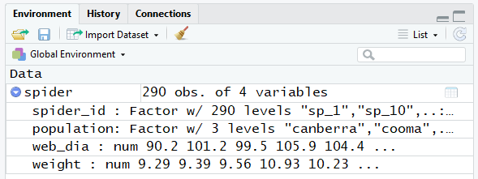

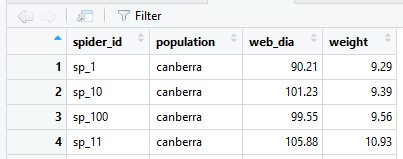

## Calculate basic statistics:

Calculate mean and standard deviation for columns `web_dia` and `weight`.

```r
print("mean and sd from web_dia")
```

```
## [1] "mean and sd from web_dia"
```

```r
mean(spider$web_dia)
```

```
## [1] 75.53214
```

```r
sd(spider$web_dia)
```

```
## [1] 36.68706
```

```r
density(spider$web_dia)
```

```
##
## Call:
##  density.default(x = spider$web_dia)
##
## Data: spider$web_dia (290 obs.); Bandwidth 'bw' = 10.62
##
##        x                y
##  Min.   :-29.94   Min.   :5.564e-06
##  1st Qu.: 17.37   1st Qu.:1.363e-03
##  Median : 64.69   Median :4.122e-03
##  Mean   : 64.69   Mean   :5.278e-03
##  3rd Qu.:112.01   3rd Qu.:6.957e-03
##  Max.   :159.32   Max.   :1.583e-02
```

```r
print("mean and sd from weight")
```

```
## [1] "mean and sd from weight"
```

```r
mean(spider$weight)
```

```
## [1] 8.293517
```

```r
sd(spider$weight)
```

```
## [1] 2.942015
```

```r
density(spider$weight)
```

```
##
## Call:
##  density.default(x = spider$weight)
##
## Data: spider$weight (290 obs.);  Bandwidth 'bw' = 0.8519
##
##        x                y
##  Min.   :-1.926   Min.   :2.068e-05
##  1st Qu.: 2.762   1st Qu.:6.532e-03
##  Median : 7.450   Median :4.785e-02
##  Mean   : 7.450   Mean   :5.328e-02
##  3rd Qu.:12.138   3rd Qu.:8.761e-02
##  Max.   :16.826   Max.   :1.444e-01
```

We can also quickly get *basic statistics* with function `summary()`:

```r
summary(spider)
```

```
##    spider_id      population    web_dia           weight
##  sp_1   :  1   canberra:96   Min.   :  1.93   Min.   : 0.630
##  sp_10  :  1   cooma   :97   1st Qu.: 38.32   1st Qu.: 6.110
##  sp_100 :  1   jervis  :97   Median : 89.53   Median : 8.950
##  sp_101 :  1                 Mean   : 75.53   Mean   : 8.294
##  sp_102 :  1                 3rd Qu.:104.34   3rd Qu.:10.565
##  sp_103 :  1                 Max.   :127.45   Max.   :14.270
##  (Other):284
```

Now a real chellenge: How to perform the same calculations as above, but using data from only the Canberra population? We will subset rows of our data using indexing *by logical expression*. We will also access the column (web_dia or weight) indexing *by name of the column*.

```r
print("mean and sd from web_dia for canberra")
```

```
## [1] "mean and sd from web_dia for canberra"
```

```r
mean(spider[spider$population == "canberra", "web_dia"])
```

```
## [1] 100.2065
```

```r
sd(spider[spider$population == "canberra", "web_dia"])
```

```
## [1] 12.98199
```

```r
print("mean and sd from weight for canberra")
```

```
## [1] "mean and sd from weight for canberra"
```

```r
mean(spider[spider$population == "canberra", "weight"])
```

```
## [1] 10.04594
```

```r
sd(spider[spider$population == "canberra", "weight"])
```

```
## [1] 1.149054
```

## Present the data on basic graphs:

For data exploration nothing works better than actually *seeing* the data. Lets make a few basic graphs allowing us to better understand the structure of the data and detect any possible trends:

Histogram - function `hist()`:

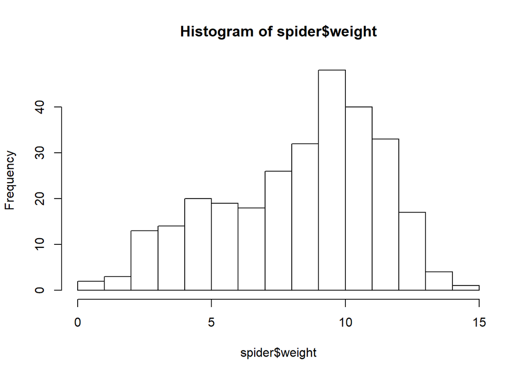

```r
hist(spider$weight)
```

XY graph (Scatter Plot) - function `plot()`:

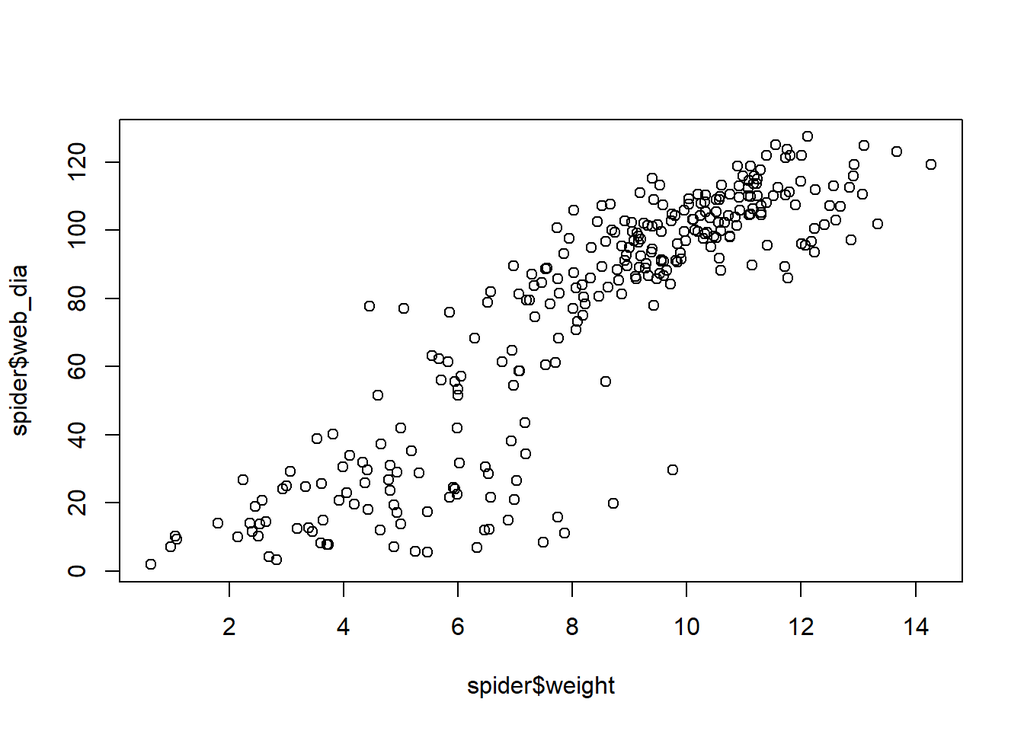

```r
plot(spider$weight, spider$web_dia)
```

Density plot:  
We will use context awareness of the `plot` function - it’s ability to make diffrent plots from objects of different classes:

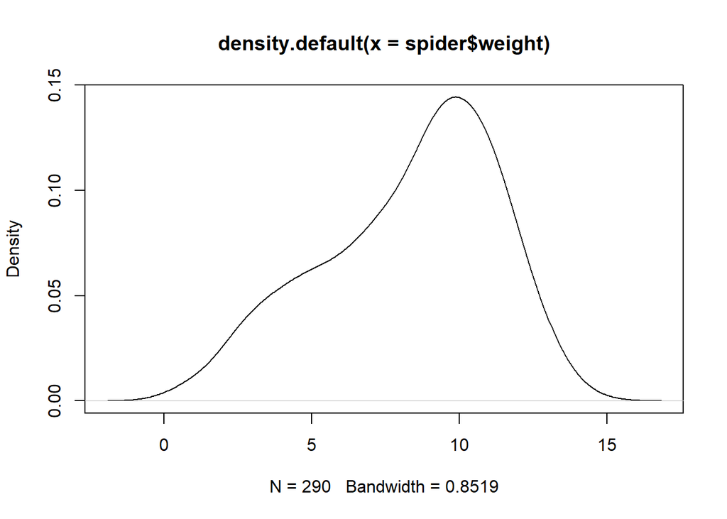

```r
plot(density(spider$weight))
```

We can even include additional series of data with the `lines()` function:

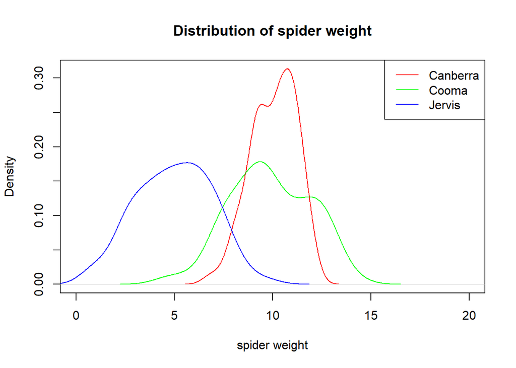

```r
plot(density(spider[spider$population == "canberra", ]$weight), xlim=c(0, 20), col = "red", main = "Distribution of spider weight", xlab = "spider weight")
lines(density(spider[spider$population == "cooma", ]$weight), col = "green")
lines(density(spider[spider$population == "jervis", ]$weight), col = "blue")

#We can also add a legend:
legend("topright", legend = c("Canberra", "Cooma", "Jervis"), col = c("red", "green", "blue"), lty = 1)
```

And repeat the same for the web diameters:

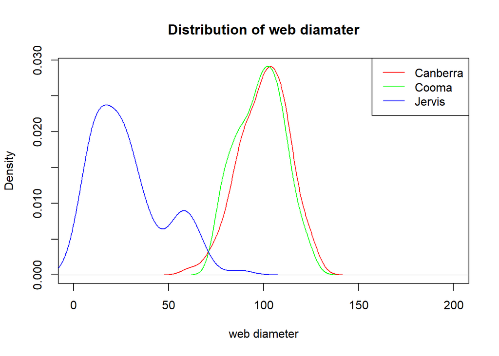

```r
plot(density(spider[spider$population == "canberra", ]$web_dia), xlim=c(0, 200), col = "red", main = "Distribution of web diamater", xlab = "web diameter")
lines(density(spider[spider$population == "cooma", ]$web_dia), col = "green")
lines(density(spider[spider$population == "jervis", ]$web_dia), col = "blue")
legend("topright", legend = c("Canberra", "Cooma", "Jervis"), col = c("red", "green", "blue"), lty = 1)
```

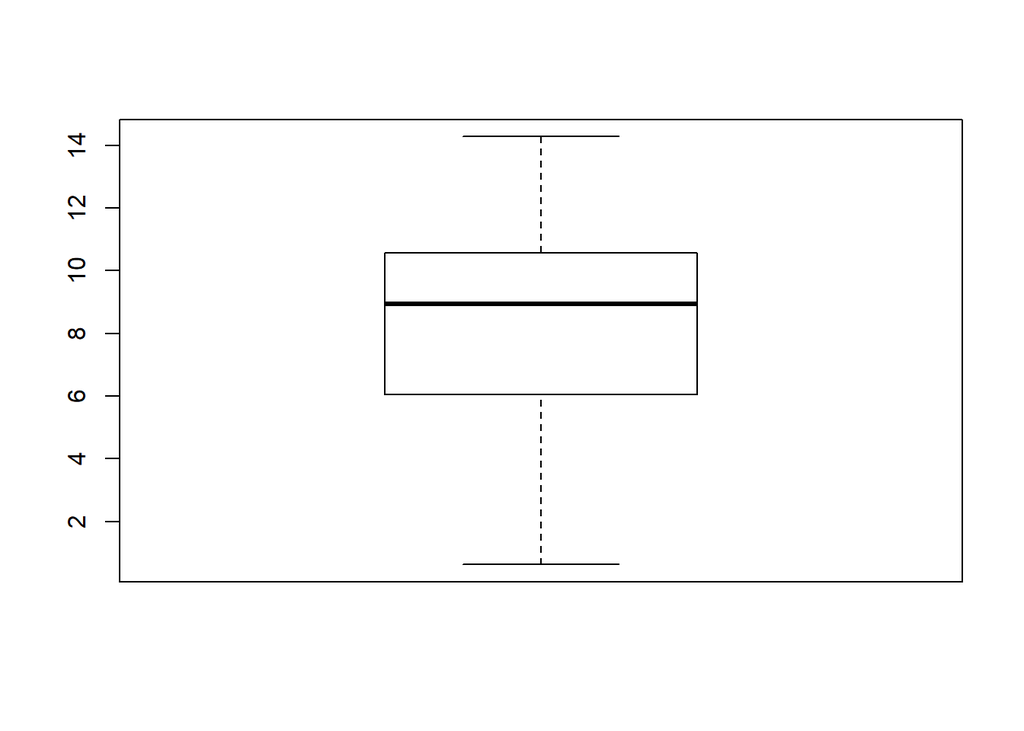

```r
boxplot(spider$weight)
```

We can put multiple data series on a boxplot by using a *formula* `~`:

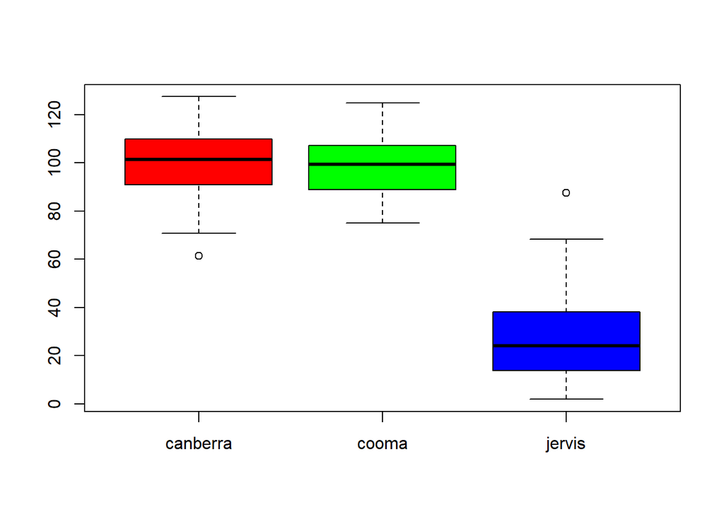

```r
boxplot(web_dia ~ population, spider, col = c("red", "green", "blue"))
```

> The *tilde* `~` operator is used to create a *formula*. Speaking English: It means that the element on the left side of tilde is in some kind of functional relation with the element on the right of the tilde. E.g. `y ~ x` means that `y` is functionally related to `x`, but we do not exactly define the nature of the ralation. It is like the old good y = f(x) statemen in algebra.

Judging from the density and box -plots: Do you see differences between the three spider populations? If yes, which populations are different?

## Test for statistical significance with t-test

To formally test for the differences, we will use the **t-test** (two-sample unpaired; more on t-test [here](https://statistics.berkeley.edu/computing/r-t-tests)) to check if there is statistically significant difference between the populations. In this kind of test, our *NULL*, or *H0* hypothesis is that there are **no differences**. To **reject the *NULL* hypothesis** (meaning there are differences after all) we need the test’s p-value to be below certain level. Usually the level is expected to be equal or below 0.05 (meaning we are at least 95% sure there are diffrences), or 0.01 (meaning 99% of certainty).

Doing the pairwise t-test on spider weight between Canberra and Cooma populations:

```r
t.test(spider[spider$population == "canberra", "weight"], spider[spider$population == "cooma", "weight"])
```

```
##
##  Welch Two Sample t-test
##
## data:  spider[spider$population == "canberra", "weight"] and spider[spider$population == "cooma", "weight"]
## t = 0.69653, df = 150.39, p-value = 0.4872
## alternative hypothesis: true difference in means is not equal to 0
## 95 percent confidence interval:
##  -0.3078122  0.6429862
## sample estimates:
## mean of x mean of y
## 10.045937  9.878351
```

```r
t.test(spider[spider$population == "jervis", "weight"], spider[spider$population == "cooma", "weight"])
```

```
##
##  Welch Two Sample t-test
##
## data:  spider[spider$population == "jervis", "weight"] and spider[spider$population == "cooma", "weight"]
## t = -17.066, df = 191.09, p-value < 2.2e-16
## alternative hypothesis: true difference in means is not equal to 0
## 95 percent confidence interval:
##  -5.470808 -4.337233
## sample estimates:
## mean of x mean of y
##  4.974330  9.878351
```

What is our conclusion this time?  
What should we change in the satements above to compare the web diameters instead of spider weights?  
T-test, although powerful and commonly used by scientists assumes that the data were sampled from normal distributions (classical t-test also assumes equal variance). How do we confirm that our data were indeed normally distributed? Formally, we should run a **test for normality**, e.g. Shapiro-Wilk Normality Test using the `shapiro.test()` function. Alternatively, we can visualize how well our data point fit the theoretical normal distribution with a Quantile-Quantile Plot using `qqnorm()` and `qqline()` functions:

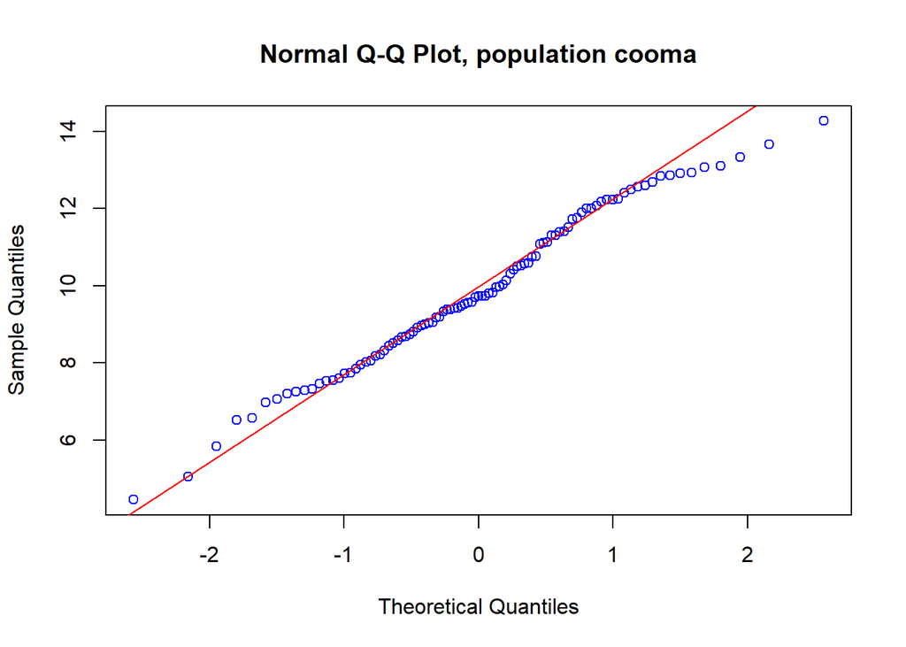

```r
#spider weight in cooma population
pop <- "cooma"
qqnorm(spider[spider$population == pop, "weight"], col = "blue", main = paste("Normal Q-Q Plot, population", pop)) #to plot the data points
qqline(spider[spider$population == pop, "weight"], col = "red")  #to fit the line
```

Please note the use of the variable `pop`. By changing the value assigned to `pop` we can easily generate this plot for any other population. How could we introduce a second variable to allow for an easy choice between comparisons for spider weights and web-diameters?